# Project 4 - Write a Data Science Blog Post

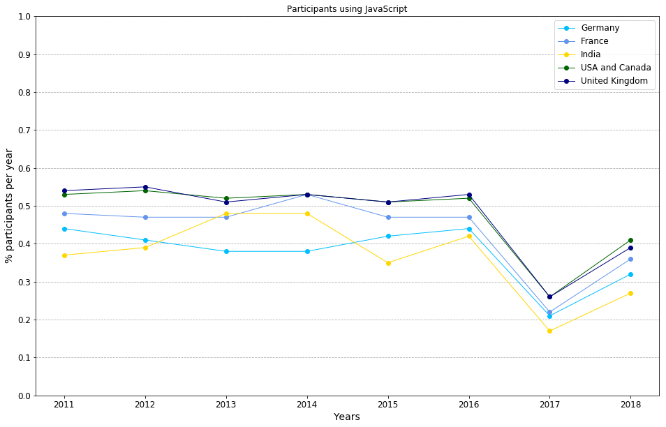

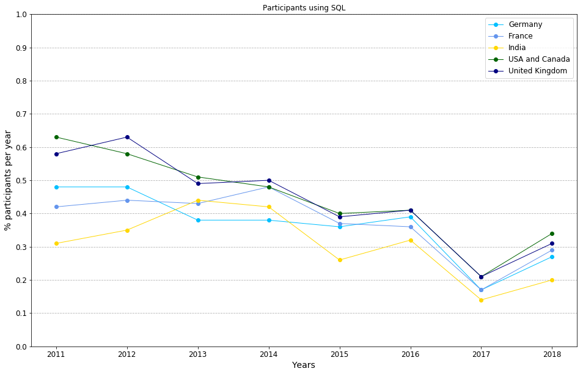

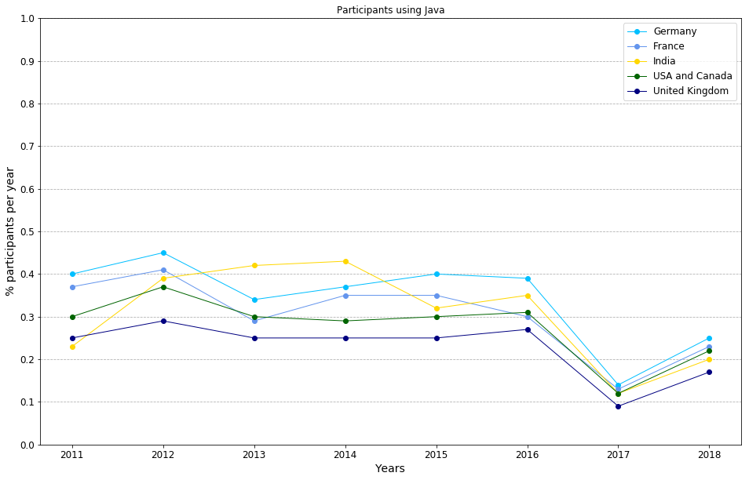

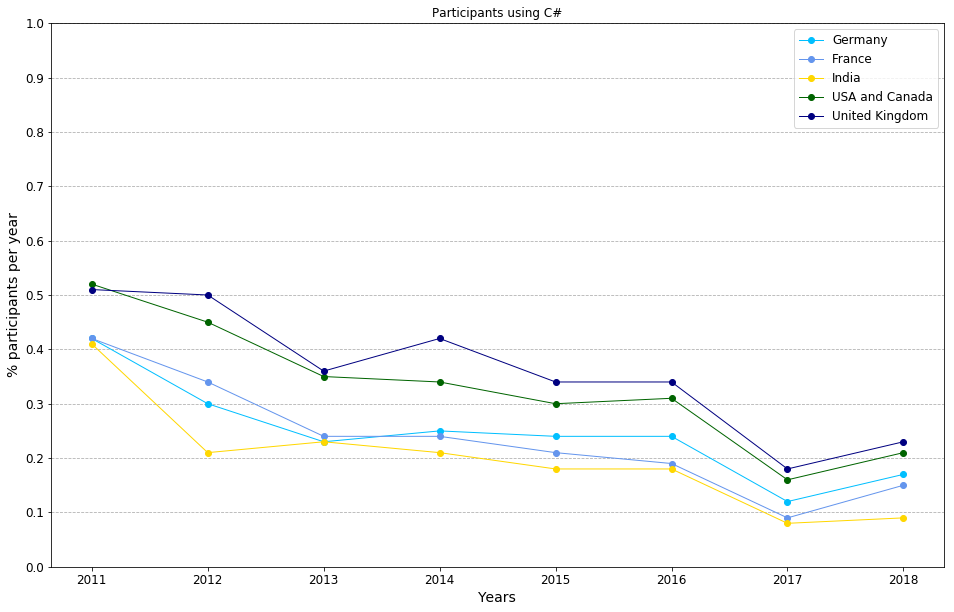

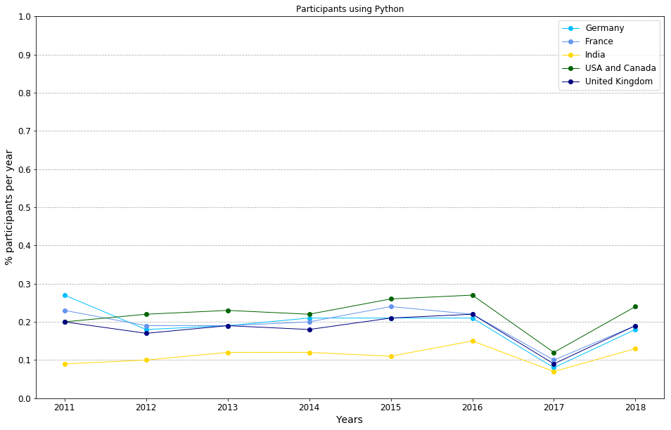

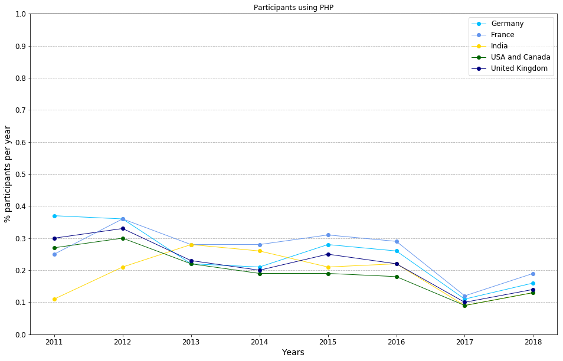

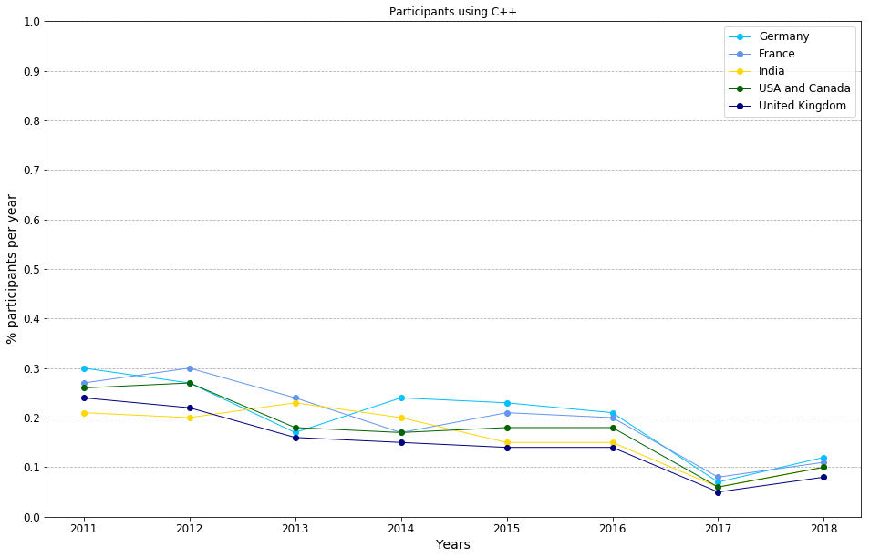

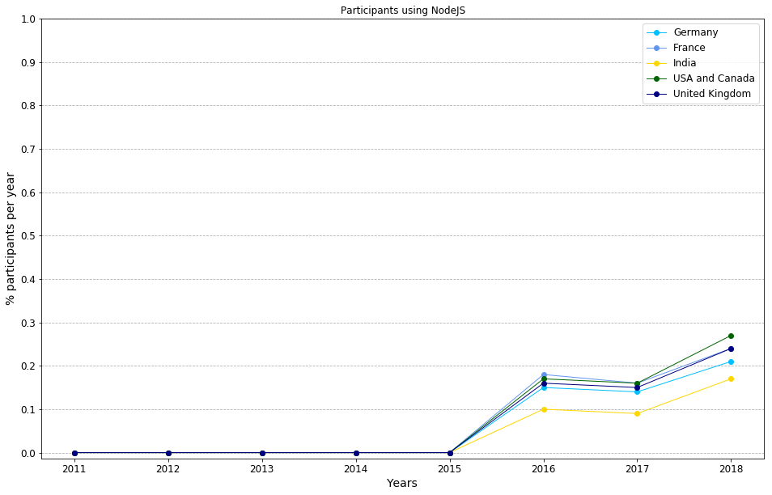

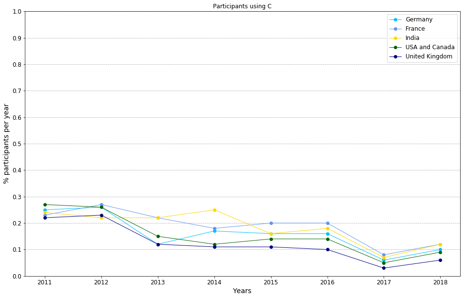

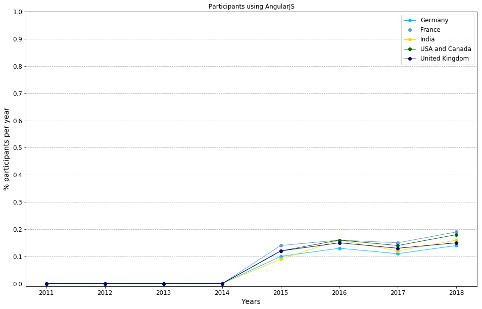

```python
for lang in top_languages:
    plot_df(top_lang_data[lang].fillna(0),
        columns = ['Germany', 'France', 'India', 'USA and Canada', 'United Kingdom'],
        color_dict = region_colors,
        title = 'Participants using '+lang,
        ylabel = '% participants per year',
        yticks=np.linspace(0,1,11))
```

```python
# for lang in top_languages:
#     plot_df(????,
#         columns = ['Europe and Russia','USA and Canada','America Other','Asia','Africa and Middle East','Australia & Oceania'],
#         color_dict = region_colors,
#         title = 'Participants using '+lang,
#         ylabel = '% participants per year')
```

```python
def print_abs_values(lang):
    for year in survey_years:
        print('Year {}: {} - {}'.format(year, lang, languages_per_region[year]['Europe and Russia'][lang]))
```

```python
print_abs_values('JavaScript')
```

```
Year 2011: JavaScript - 517
Year 2012: JavaScript - 1254
Year 2013: JavaScript - 1821
Year 2014: JavaScript - 1500
Year 2015: JavaScript - 6135
Year 2016: JavaScript - 13107
Year 2017: JavaScript - 5405
Year 2018: JavaScript - 14031
```

**Observations:**

The drop in the year 2017 is visible for nearly every language in every region. It is a reasonable assumption that this had other reasons than the popularity of the language dropping, such as survey design or targeting. As we cannot with certainty explain the reason behind the drop it may be better to look at the development from 2016 to 2018 as steady, thus ignoring the universal drop in 2017.

The sinking of participants using C, C++, C# and some of the other big languages may be due to the increase in language diversity on stackoverflow. It does not mean these languages actually get used less, but it may hint to stackoverflow increasing in popularity for people using other languages than the more common ones.

### Programming as a hobby

For this question we only have to look at a single column: 'Programming_Hobby'. When preparing this column we already had to reshape it to only include the information: does the participant program as a hobby. Once again we cannot differentiate properly between "did not answer" and "answered no". We'll make the assumption that every participant that programs as a hobby answered the question with yes, everyone else either skipped the question (not answering it) or answered no.

Let's create a dataframe telling us how many people program as a hobby in each region and year. Then let's use the total amount of participants in each region and year to create relative values and plot them as we did before.

```python
programming_hobby = rearrange_regional_data('Programming_Hobby', 1, [2011,2012,2013,2014])
```

```python
programming_hobby
```

|  | Africa | America Other | Asia Other | Australia & Oceania | Canada | Europe Other | France | Germany | India | Middle East | Other | Russia | United Kingdom | United States of America | Total | Europe and Russia | USA and Canada | Asia | Africa and Middle East |
| --- | --- | --- | --- | --- | --- | --- | --- | --- | --- | --- | --- | --- | --- | --- | --- | --- | --- | --- | --- |
| 2011 | 0 | 0 | 0 | 0 | 0 | 0 | 0 | 0 | 0 | 0 | 0 | 0 | 0 | 0 | 0 | 0 | 0 | 0 | 0 |
| 2012 | 0 | 0 | 0 | 0 | 0 | 0 | 0 | 0 | 0 | 0 | 0 | 0 | 0 | 0 | 0 | 0 | 0 | 0 | 0 |
| 2013 | 0 | 0 | 0 | 0 | 0 | 0 | 0 | 0 | 0 | 0 | 0 | 0 | 0 | 0 | 0 | 0 | 0 | 0 | 0 |
| 2014 | 0 | 0 | 0 | 0 | 0 | 0 | 0 | 0 | 0 | 0 | 0 | 0 | 0 | 0 | 0 | 0 | 0 | 0 | 0 |
| 2015 | 202 | 600 | 634 | 583 | 544 | 4140 | 439 | 1187 | 1196 | 320 | 0 | 346 | 1537 | 3262 | 14990 | 7649 | 3806 | 1830 | 522 |
| 2016 | 722 | 1840 | 1669 | 1217 | 1475 | 11238 | 1114 | 2914 | 2809 | 677 | 0 | 980 | 3358 | 10174 | 40187 | 19604 | 11649 | 4478 | 1399 |
| 2017 | 1028 | 1743 | 2396 | 1222 | 1780 | 9614 | 1434 | 3446 | 4202 | 1050 | 0 | 686 | 3541 | 9336 | 41478 | 18721 | 11116 | 6598 | 2078 |
| 2018 | 2201 | 4230 | 5465 | 2635 | 2716 | 17846 | 2105 | 5454 | 11056 | 1935 | 0 | 2229 | 5054 | 16646 | 79572 | 32688 | 19362 | 16521 | 4136 |

```python
participants_per_year
```

|  | Africa | America Other | Asia Other | Australia & Oceania | Canada | Europe Other | France | Germany | India | Middle East | Other | Russia | United Kingdom | United States of America | Total | Europe and Russia | USA and Canada | Asia | Africa and Middle East |
| --- | --- | --- | --- | --- | --- | --- | --- | --- | --- | --- | --- | --- | --- | --- | --- | --- | --- | --- | --- |
| 2011 | 43 | 125 | 81 | 141 | 156 | 541 | 60 | 106 | 95 | 73 | 0 | 41 | 314 | 1037 | 5626 | 1062 | 1193 | 176 | 116 |
| 2012 | 92 | 258 | 236 | 290 | 348 | 1414 | 135 | 273 | 537 | 124 | 0 | 162 | 589 | 1785 | 12486 | 2573 | 2133 | 773 | 216 |
| 2013 | 115 | 297 | 384 | 364 | 490 | 1984 | 232 | 583 | 737 | 198 | 0 | 241 | 935 | 3181 | 19482 | 3975 | 3671 | 1121 | 313 |
| 2014 | 108 | 251 | 369 | 244 | 306 | 1613 | 198 | 455 | 881 | 195 | 8 | 166 | 721 | 2128 | 15286 | 3153 | 2434 | 1250 | 303 |
| 2015 | 382 | 1031 | 1314 | 882 | 828 | 7227 | 776 | 1976 | 2461 | 599 | 5 | 650 | 2403 | 4745 | 50558 | 13032 | 5573 | 3775 | 981 |
| 2016 | 1003 | 2464 | 2537 | 1650 | 2024 | 15531 | 1626 | 3883 | 4193 | 1055 | 30 | 1419 | 4573 | 13539 | 111054 | 27032 | 15563 | 6730 | 2058 |
| 2017 | 1245 | 2277 | 3012 | 1464 | 2233 | 11782 | 1756 | 4143 | 5197 | 1398 | 151 | 873 | 4402 | 11458 | 102782 | 22956 | 13691 | 8209 | 2643 |
| 2018 | 2753 | 5472 | 6865 | 3220 | 3393 | 21874 | 2572 | 6459 | 13721 | 2630 | 84 | 2869 | 6221 | 20309 | 196884 | 39995 | 23702 | 20586 | 5383 |

```python
programming_hobby_relative = np.around(programming_hobby / participants_per_year, decimals=2)
programming_hobby_relative
```

|  | Africa | America Other | Asia Other | Australia & Oceania | Canada | Europe Other | France | Germany | India | Middle East | Other | Russia | United Kingdom | United States of America | Total | Europe and Russia | USA and Canada | Asia | Africa and Middle East |
| --- | --- | --- | --- | --- | --- | --- | --- | --- | --- | --- | --- | --- | --- | --- | --- | --- | --- | --- | --- |
| 2011 | 0.00 | 0.00 | 0.00 | 0.00 | 0.00 | 0.00 | 0.00 | 0.00 | 0.00 | 0.00 | NaN | 0.00 | 0.00 | 0.00 | 0.00 | 0.00 | 0.00 | 0.00 | 0.00 |
| 2012 | 0.00 | 0.00 | 0.00 | 0.00 | 0.00 | 0.00 | 0.00 | 0.00 | 0.00 | 0.00 | NaN | 0.00 | 0.00 | 0.00 | 0.00 | 0.00 | 0.00 | 0.00 | 0.00 |
| 2013 | 0.00 | 0.00 | 0.00 | 0.00 | 0.00 | 0.00 | 0.00 | 0.00 | 0.00 | 0.00 | NaN | 0.00 | 0.00 | 0.00 | 0.00 | 0.00 | 0.00 | 0.00 | 0.00 |
| 2014 | 0.00 | 0.00 | 0.00 | 0.00 | 0.00 | 0.00 | 0.00 | 0.00 | 0.00 | 0.00 | 0.0 | 0.00 | 0.00 | 0.00 | 0.00 | 0.00 | 0.00 | 0.00 | 0.00 |
| 2015 | 0.53 | 0.58 | 0.48 | 0.66 | 0.66 | 0.57 | 0.57 | 0.60 | 0.49 | 0.53 | 0.0 | 0.53 | 0.64 | 0.69 | 0.30 | 0.59 | 0.68 | 0.48 | 0.53 |
| 2016 | 0.72 | 0.75 | 0.66 | 0.74 | 0.73 | 0.72 | 0.69 | 0.75 | 0.67 | 0.64 | 0.0 | 0.69 | 0.73 | 0.75 | 0.36 | 0.73 | 0.75 | 0.67 | 0.68 |
| 2017 | 0.83 | 0.77 | 0.80 | 0.83 | 0.80 | 0.82 | 0.82 | 0.83 | 0.81 | 0.75 | 0.0 | 0.79 | 0.80 | 0.81 | 0.40 | 0.82 | 0.81 | 0.80 | 0.79 |
| 2018 | 0.80 | 0.77 | 0.80 | 0.82 | 0.80 | 0.82 | 0.82 | 0.84 | 0.81 | 0.74 | 0.0 | 0.78 | 0.81 | 0.82 | 0.40 | 0.82 | 0.82 | 0.80 | 0.77 |

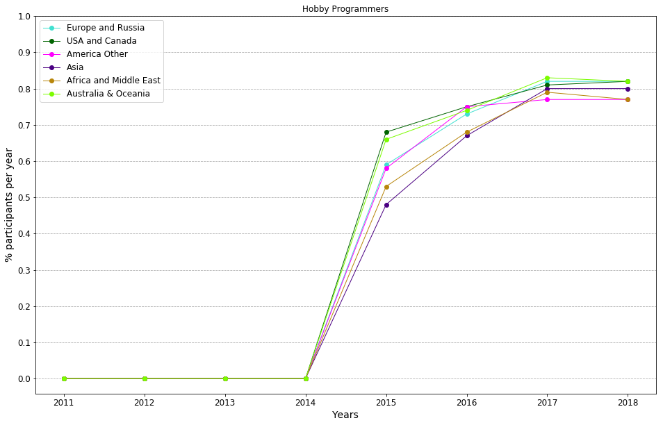

```python
plot_aggregate_regions(programming_hobby_relative, nan_as_zero=False, title='Hobby Programmers')
```

**Observations:**

### Company Size

Here, we can use the same procedure as we did for age and satisfaction. We'll create 4 dataframes, one for each of the size categories. As usual we'll create relative values and then plot them out.

```python
print('Number of missing entries in Company_Size')
for year in survey_years:
    if year in [2014,2015]:
        continue
    print(str(np.around(1-survey_results[year]['Company_Size'].count()/survey_results[year]['Company_Size'].shape[0],
                        decimals=4)*100)+' %')
```

```
Number of missing entries in Company_Size
5.94 %
8.110000000000001 %
15.64 %
28.73 %
24.26 %
27.639999999999997 %
```

As with age and satisfaction before we'll only look at the people who have actually answered this question and use them as a total.

```python
company_extra_small = rearrange_regional_data('Company_Size', 1, [2014,2015])
company_small = rearrange_regional_data('Company_Size', 2, [2014,2015])
company_medium = rearrange_regional_data('Company_Size', 3, [2014,2015])
company_large = rearrange_regional_data('Company_Size', 4, [2014,2015])
```

```python
company_size_answered = company_extra_small + company_small + company_medium + company_large
```

```python
company_extra_small = np.around(company_extra_small / company_size_answered, decimals=2)
company_small = np.around(company_small / company_size_answered, decimals=2)
company_medium = np.around(company_medium / company_size_answered, decimals=2)
company_large = np.around(company_large / company_size_answered, decimals=2)
```

```python
company_extra_small
```

|  | Africa | America Other | Asia Other | Australia & Oceania | Canada | Europe Other | France | Germany | India | Middle East | Other | Russia | United Kingdom | United States of America | Total | Europe and Russia | USA and Canada | Asia | Africa and Middle East |
| --- | --- | --- | --- | --- | --- | --- | --- | --- | --- | --- | --- | --- | --- | --- | --- | --- | --- | --- | --- |
| 2011 | 0.32 | 0.46 | 0.45 | 0.32 | 0.33 | 0.42 | 0.35 | 0.38 | 0.28 | 0.38 | NaN | 0.32 | 0.34 | 0.24 | 0.32 | 0.38 | 0.25 | 0.35 | 0.36 |
| 2012 | 0.41 | 0.43 | 0.40 | 0.45 | 0.39 | 0.43 | 0.39 | 0.34 | 0.28 | 0.39 | NaN | 0.31 | 0.34 | 0.29 | 0.36 | 0.39 | 0.30 | 0.32 | 0.40 |
| 2013 | 0.53 | 0.47 | 0.39 | 0.45 | 0.43 | 0.44 | 0.42 | 0.43 | 0.28 | 0.47 | NaN | 0.37 | 0.39 | 0.29 | 0.37 | 0.42 | 0.30 | 0.32 | 0.49 |
| 2014 | NaN | NaN | NaN | NaN | NaN | NaN | NaN | NaN | NaN | NaN | NaN | NaN | NaN | NaN | NaN | NaN | NaN | NaN | NaN |
| 2015 | NaN | NaN | NaN | NaN | NaN | NaN | NaN | NaN | NaN | NaN | NaN | NaN | NaN | NaN | NaN | NaN | NaN | NaN | NaN |
| 2016 | 0.38 | 0.35 | 0.32 | 0.31 | 0.26 | 0.33 | 0.32 | 0.30 | 0.24 | 0.37 | NaN | 0.28 | 0.29 | 0.20 | 0.28 | 0.32 | 0.21 | 0.27 | 0.37 |
| 2017 | 0.30 | 0.25 | 0.28 | 0.25 | 0.21 | 0.24 | 0.25 | 0.20 | 0.21 | 0.32 | NaN | 0.20 | 0.21 | 0.14 | 0.21 | 0.23 | 0.15 | 0.24 | 0.31 |
| 2018 | 0.35 | 0.28 | 0.28 | 0.27 | 0.21 | 0.24 | 0.24 | 0.20 | 0.21 | 0.31 | NaN | 0.19 | 0.21 | 0.14 | 0.22 | 0.23 | 0.15 | 0.23 | 0.32 |

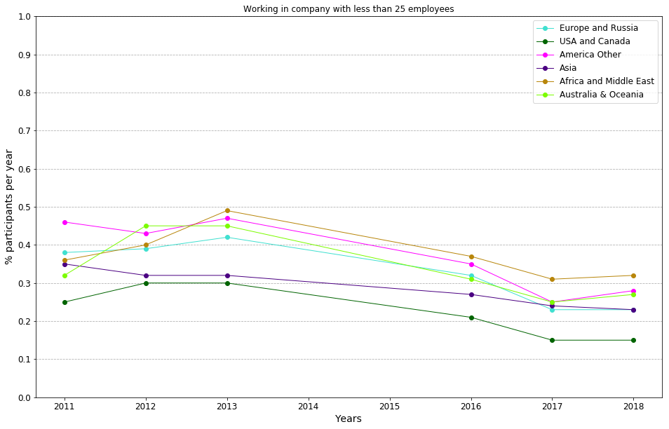

```python
plot_aggregate_regions(company_extra_small, title='Working in company with less than 25 employees')
```

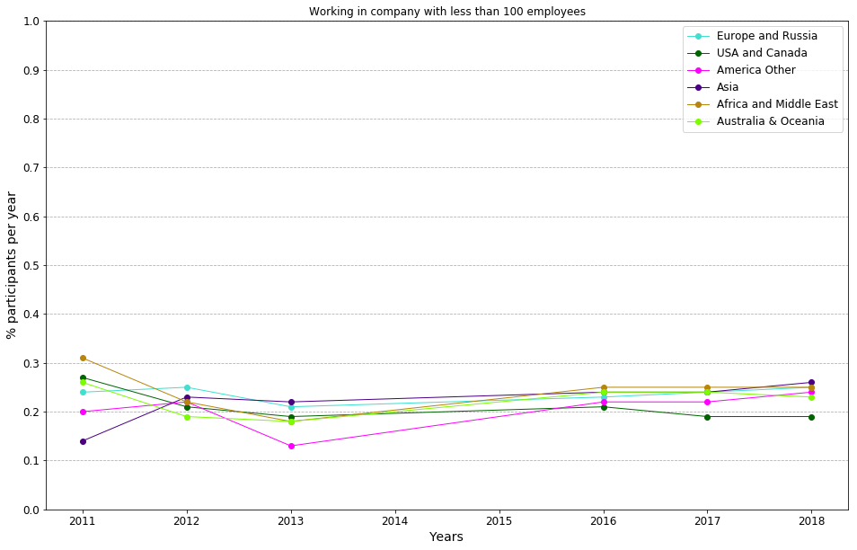

```python
plot_aggregate_regions(company_small, title='Working in company with less than 100 employees')
```

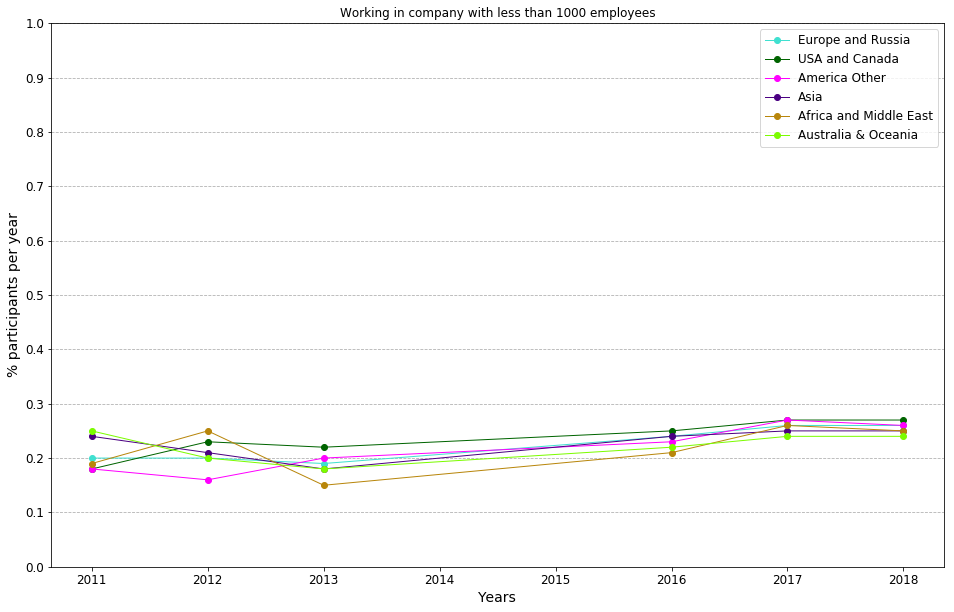

```python
plot_aggregate_regions(company_medium, title='Working in company with less than 1000 employees')
```

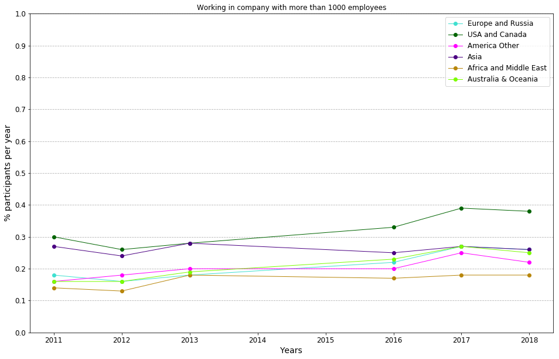

```python
plot_aggregate_regions(company_large, title='Working in company with more than 1000 employees')
```

**Observations:**

- Africa has the lowest percentage of people working in large companiesand has a comparatively high percentage of people working in very small companies.
- USA and Canada have a lower percentage of people working in very small companies compared to the other regions. They have a larger share of people working in medium sized companies and a significantly larger share than all other regions working in large companies with more than 1000 employees.
- For both very small and large companies the spread between the regions is much larger than in the small to medium sized companies.